# Examining ADCP Data from the ETNP19 Kilo Moana Cruise

author: “Jacob Cram”

email: “jcram@umces.edu”

modified: "November 2019

The point of this script was, on the KM, to check the amplitude signal on the ADCP. It has been modified to look at data after the cruise was over. Currently files are not fully up to date.

# Load in Required packages

```r
library(oce)
library(ncdf4)
library(tidyverse)
library(viridis)
library(lubridate)
```

# Load in the narrow band data.

This can be ammended in order to use data from broadband or workhorse adcp sensors

```r
ncdfName <- "os38nb.nc"
```

```r
data38nb <- read.netcdf(ncdfName)
```

# Some initial processing

```r
allDepth <- data38nb@data$depth
depthL <- dim(allDepth)[1]
oneDepth <- allDepth[,depthL]
oneDepth
```

```
 [1]   46.91   70.91   94.91  118.91  142.91  166.91  190.91  214.91  238.91  262.91  286.91  310.91  334.91  358.91  382.91  406.91  430.91  454.91  478.91  502.91
[21]  526.91  550.91  574.91  598.91  622.91  646.91  670.91  694.91  718.91  742.91  766.91  790.91  814.91  838.91  862.91  886.91  910.91  934.91  958.91  982.91
[41] 1006.91 1030.91 1054.91 1078.91 1102.91 1126.91 1150.91 1174.91 1198.91 1222.91 1246.91 1270.91 1294.91 1318.91 1342.91 1366.91 1390.91 1414.91 1438.91 1462.91
[61] 1486.91 1510.91 1534.91 1558.91 1582.91 1606.91 1630.91 1654.91 1678.91 1702.91 1726.91 1750.91 1774.91 1798.91 1822.91
```

```r
standInTime <- 1:dim(allDepth)[2]
standInTime %>% head
```

```
[1] 1 2 3 4 5 6
```

```r
lastRead <- dim(allDepth)[2]
```

# Pull in time data.

Doesn’t work with oce package, but does with ncdf4, so I’m doing that.

```r
ncin <- nc_open(ncdfName)
#print(ncin)
time <- ncvar_get(ncin, "time")
time %>% head
```

```
[1] 274.5048 274.5083 274.5118 274.5152 274.5187 274.5222
```

```r
decimalDate <- 2019 + time/365
date <- date_decimal(decimalDate)
```

```r
time2 <- sapply(time, function(x) paste(x, "2019", sep = "-"))
```

# Plot of all of the ADCP data from the whole second leg of the cruise.

All dates are in UTC. One could in theory convert to local time.

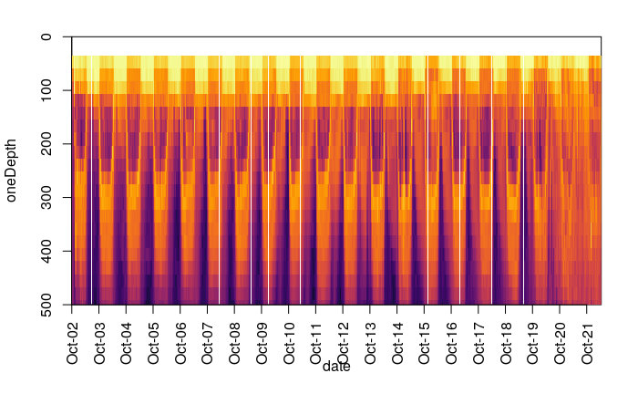

```r
image(x = date, y = oneDepth,  z = t(data38nb@data$amp), ylim = c(500, 0), col = inferno(100), xaxt = "n")
dr <- range(date)
axis.POSIXct(1, seq(dr[1], dr[2], by = "day"), at = seq(dr[1], dr[2], by = "day"), format = "%b-%d", las = 2)
```

#Zoom in. This is data from two days that we were sampling. You can see the two deep adcp bands that migrate over the course of the day. The migration starts at dawn and ends at dusk. There is a secondary nighttime migration visible as well.

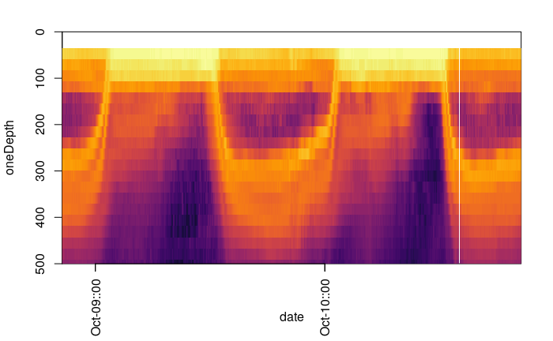

```r
timeWindowEnd <- as.POSIXct("2019-10-10 20:31:54", tz = "UTC")
timeWindowStart <- timeWindowEnd - 60 * 60 * 24 * 2
image(x = date, y = oneDepth,  z = t(data38nb@data$amp), ylim = c(500, 0),
      xlim = c(timeWindowStart, timeWindowEnd),
      col = inferno(100), xaxt = "n")
axis.POSIXct(1, seq(timeWindowStart, timeWindowEnd, by = "hour"), format = "%b-%d::%H", las = 2)
```

# Correcting time zones.

```r
# the below doesn't actually change the time zone, just what the time zone is called
#dateMex <- as.POSIXct(date, tz = "Mexico/General")
dateMex <- as.POSIXct(date, tz = "UTC")
attributes(dateMex)$tzone <- "Mexico/General"
```

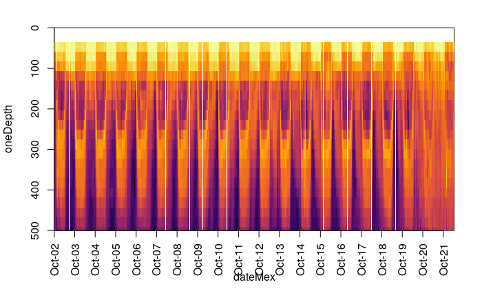

```r
image(x = dateMex, y = oneDepth,  z = t(data38nb@data$amp), ylim = c(500, 0), col = inferno(100), xaxt = "n")
dr <- range(date)
axis.POSIXct(1, seq(dr[1], dr[2], by = "day"), at = seq(dr[1], dr[2], by = "day"), format = "%b-%d", las = 2)
```

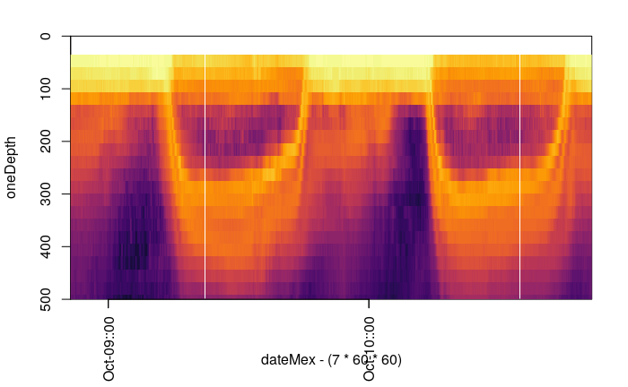

```r
timeWindowEnd <- as.POSIXct("2019-10-10 20:31:54", tz = "UTC")
timeWindowStart <- timeWindowEnd - 60 * 60 * 24 * 2
image(x = dateMex-(7*60*60), y = oneDepth,  z = t(data38nb@data$amp), ylim = c(500, 0), # the dates are messed up without adding this stupid fudge factor
      xlim = c(timeWindowStart, timeWindowEnd),
      col = inferno(100), xaxt = "n")
axis.POSIXct(1, seq(timeWindowStart, timeWindowEnd, by = "hour"), format = "%b-%d::%H", las = 2)
```

# Looking at two stations seperately

```r
lats <- ncvar_get(ncin, "lat")
lons <- ncvar_get(ncin, "lon")
```

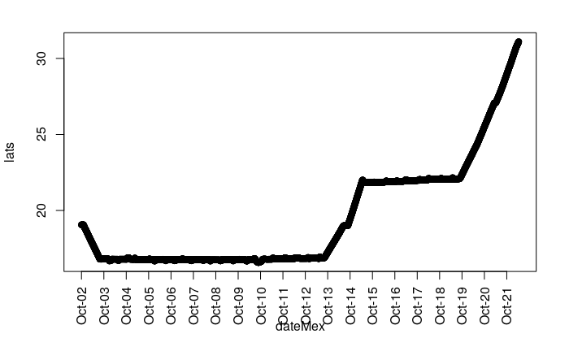

```r
plot(dateMex, lats, xaxt = "n")
axis.POSIXct(1, seq(dr[1], dr[2], by = "day"), at = seq(dr[1], dr[2], by = "day"), format = "%b-%d", las = 2)
```

```r
P2_Timepoints <-  dateMex > as.POSIXct("2019-10-03") & dateMex < as.POSIXct("2019-10-12")
P3_Timepoints <-  dateMex > as.POSIXct("2019-10-15") & dateMex < as.POSIXct("2019-10-19 22:00:00")
Day_Timepoints <- hour(dateMex) > 11 & hour(dateMex) < 13
Night_Timepoints <-  hour(dateMex) > 23 | hour(dateMex ) < 1

P2_Day <- P2_Timepoints & Day_Timepoints
P2_Night <- P2_Timepoints & Night_Timepoints
P3_Day <- P3_Timepoints & Day_Timepoints
P3_Night <- P3_Timepoints & Night_Timepoints
```

## Station P2

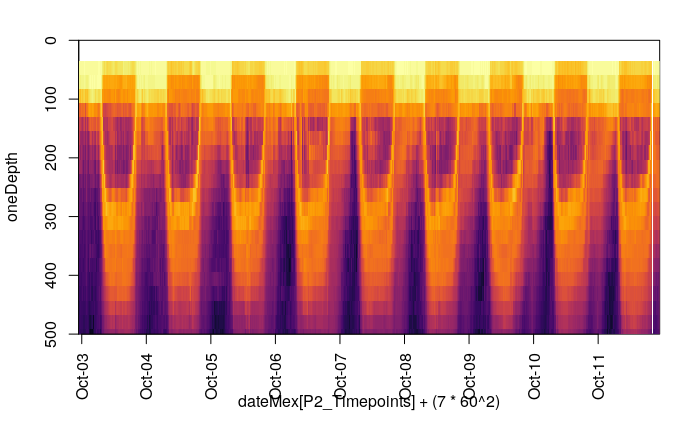

```r
image(x = dateMex[P2_Timepoints] + (7 * 60^2), y = oneDepth,  z = (t(data38nb@data$amp))[P2_Timepoints,], ylim = c(500, 0), col = inferno(100), xaxt = "n")
dr <- range(date)
axis.POSIXct(1, seq(dr[1], dr[2], by = "day"), at = seq(dr[1], dr[2], by = "day"), format = "%b-%d", las = 2)
```

## Station P3

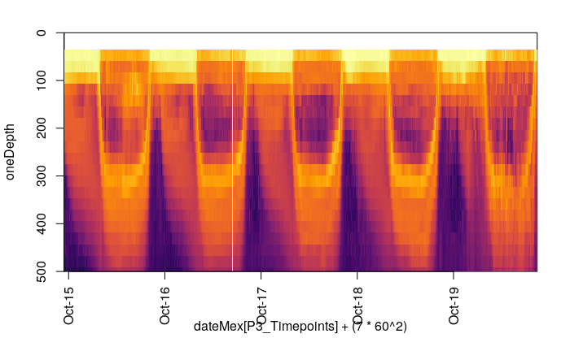

```r
image(x = dateMex[P3_Timepoints] + (7 * 60^2), y = oneDepth,  z = (t(data38nb@data$amp))[P3_Timepoints,], ylim = c(500, 0), col = inferno(100), xaxt = "n")
dr <- range(date)
axis.POSIXct(1, seq(dr[1], dr[2], by = "day"), at = seq(dr[1], dr[2], by = "day"), format = "%b-%d", las = 2)
```

## Average over stations

```r
P2_mean <- apply(t(data38nb@data$amp)[P2_Timepoints,], MARGIN = 2, FUN = mean)
P3_mean <- apply(t(data38nb@data$amp)[P3_Timepoints,], MARGIN = 2, FUN = mean)

P2_day_mean <- apply(t(data38nb@data$amp)[P2_Day,], MARGIN = 2, FUN = mean)
P3_day_mean <- apply(t(data38nb@data$amp)[P3_Day,], MARGIN = 2, FUN = mean)
P2_night_mean <- apply(t(data38nb@data$amp)[P2_Night,], MARGIN = 2, FUN = mean)
P3_night_mean <- apply(t(data38nb@data$amp)[P3_Night,], MARGIN = 2, FUN = mean)
```

```r
dayNightPlot <- function(){
plot(x = P2_day_mean, y = oneDepth, ylim = rev(c(0, 500)), type = "l", col = "darkgreen")
lines(x = P3_day_mean, y = oneDepth, col = "darkblue")
lines(x = P2_night_mean, y = oneDepth, col = "darkgreen", lty = "dashed")
lines(x = P3_night_mean, y = oneDepth, col = "darkblue", lty = "dashed")
}
dayNightPlot()

png("DayNightP2P3.png", width = 3, height = 5, units = "in", res = 100)
```

[figure not shown]

```r
dayNightPlot()
dev.off()
```